# Collections

### Collections

Java has several ways to hold objects(or rather, references to objects). An array is the most efficient way to hold a group of objects, and you’re pointed towards this choice to hold a group of primitives. But an array has a fixed size, and in the more general case, you won’t know at the time you’re writing the program how many objects you’re going to need, or whether you need a more sophisticated way to store your objects—so the fixed-sized constraint of an array is too limiting.

#### java.util

The java.util library has a reasonably complete set of collection classes to solve this problem, the basic types of which are **List**, **Set**, **Queue**, and **Map**. These types are also known as container classes. Collections provide sophisticated ways to hold objects, and solve a surprising number of problems.

Among their other characteristics— Set, holds only one object of each value, and Map is an associative array that lets us associate objects with other objects. All Java collections can be resized. So, unlike arrays, you can put in any number of objects without worrying about how big the collection should be.

### Type-Safe Collections

Before Java 5 all the collections allowed you to put any type of object. For example, let's consider collection of apples using **ArrayList**.

In this example, Apples and Orange s are placed into the collection, then pulled out. Normally, the Java compiler will give you a warning because the example does not use generics.

```java
import java.util.*;

class Apple {
    private static long counter = 0;
    private final long id = counter++;

    public long getId() {
        return id;
    }
}

class Orange {}

class ApplesAndOrangesWithoutGenerics {
    public static void main(String[] args) {
        ArrayList apples = new ArrayList();
        Apple apple = new Apple();
        Orange orange = new Orange();

        apples.add(apple);
        apples.add(orange);

        for (Object o : apples) {
            System.out.println("id is " + ((Apple) o).getId());
        }
    }
}
```

```java
ApplesAndOrangesWithoutGenerics.main(new String[]{});
```

```
id is 0
```

```
---------------------------------------------------------------------------
java.lang.ClassCastException: class REPL.$JShell$13$Orange cannot be cast to class REPL.$JShell$12$Apple (REPL.$JShell$13$Orange and REPL.$JShell$12$Apple are in unnamed module of loader jdk.jshell.execution.DefaultLoaderDelegate$RemoteClassLoader @5e0826e7)
	at ApplesAndOrangesWithoutGenerics.main(#14:1)
	at .(#15:1)
```

The classes Apple and Orange are distinct; they have nothing in common except they are both Objects. Since ArrayList holds Object s, you can not only add Apple objects into this collection using the ArrayList method add() , but you can also add Orange objects without complaint at either compile time or run time.

When you go to fetch out what you think are Apple objects using the ArrayList method get() , you get back a reference to an Object you must cast to an Apple. At run time, when you try to cast the Orange object to an Apple , you get the error as shown in the output.

To define an ArrayList intended to hold Apple objects, you say ArrayList < Apple > instead of just ArrayList. The angle brackets surround the type parameter(s) (there might be more than one), which specify the type(s) that can be held by that instance of the collection.

```java
import java.util.*;

public class ApplesAndOrangesWithGenerics {
    public static void main(String[] args) {
        ArrayList<Apple>apples = new ArrayList<>();
        for (int i = 0; i < 3; i++) {
            apples.add(new Apple());
        }
        // Compile-time error:
//         apples.add(new Orange());
        for (Apple apple : apples) {
            System.out.println(apple.getId());
        }
    }
}
```

```java
ApplesAndOrangesWithGenerics.main(new String[] {});
```

```
1
2
3
```

The syntax of collection creation is following:

```java
ArrayList<int> ints = new ArrayList<>();
```

```
|   ArrayList<int> ints = new ArrayList<>();
unexpected type
  required: reference
  found:    int
```

```java
ArrayList<Integer> ints = new ArrayList<>();
ints.add(10);
```

```
true
```

or

With the type specified in the ArrayList definition, the compiler prevents you from putting an Orange into apples , so it becomes a compile-time error rather than a runtime error.

With generics, the cast is not necessary when fetching items from the List . Since the List knows what type it holds, it does the cast for you when you call get().

### Generics and upcasting

You are not limited to putting the exact type of object into a collection when you specify that type as a generic parameter. Upcasting works the same with generics as it does with other types:

```java
import java.util.*;

class Car {}
class Honda extends Car {}
class Mercedes extends Car {}
class Toyota extends Car {}

public class GenericsUpcasting {

    public static void main(String[] args) {
        ArrayList<Car> cars = new ArrayList<>();
        cars.add(new Car());
        cars.add(new Honda());
        cars.add(new Mercedes());
        cars.add(new Toyota());

        for (Car car : cars) {
            System.out.println(car);
        }
    }
}
```

```java
GenericsUpcasting.main(new String[]{});
```

```
REPL.$JShell$19$Car@64b545d7
REPL.$JShell$20$Honda@6a72b731
REPL.$JShell$21$Mercedes@6e4d2ea7
REPL.$JShell$22$Toyota@2b4fbd0a
```

Thus, you can add a subtype of Car to a collection specified to hold Car objects.

### Collection

Collection is a sequence of individual elements with one or more rules applied to them. A **List** must hold the elements in the way they were inserted. A **Set** cannot have duplicate elements. The **Queue** produces the elements in the order determined by a queuing discipline. **Map** - a group of key-value pairs that looks up a value using a key. **ArrayList** - looks up an object using indexes. A map looks up an object using another object.

### List

public interface List extends Collection

A list is an ordered collection (also known as a sequence). The user of this interface has precise control over where in the list each element is inserted. The user can access elements by their integer index (position in the list), and search for elements in the list. Two most frequetly used list implementation classes are **ArrayList** and **LinkedList**.

Thus, you can create a List like this:  
`List < Apple > apples = new ArrayList <>();`

Notice that the ArrayList is upcast to a List.

The intent of using the interface is that if you decide to change your implementation, you just change it at the point of creation, like this:  
`List < Apple > apples = new LinkedList <>();`

This approach won’t always work, because some classes have additional functionality. For example, LinkedList has additional methods not in the List interface, and a TreeMap has methods not in the Map interface.

```java
import java.util.*;

public class CollectionDemo {
    public static void main(String... args) {
        Collection<Integer> c = new ArrayList<>();
        for (int i = 0; i < 100; i++) {
            c.add(i); // Autoboxing
        }

        for (Integer i : c) {
            System.out.print(i + " ");
        }
    }
}

CollectionDemo.main();
```

```
0 1 2 3 4 5 6 7 8 9 10 11 12 13 14 15 16 17 18 19 20 21 22 23 24 25 26 27 28 29 30 31 32 33 34 35 36 37 38 39 40 41 42 43 44 45 46 47 48 49 50 51 52 53 54 55 56 57 58 59 60 61 62 63 64 65 66 67 68 69 70 71 72 73 74 75 76 77 78 79 80 81 82 83 84 85 86 87 88 89 90 91 92 93 94 95 96 97 98 99
```

This example only uses Collection methods, so any object of a class inherited from Collection would work. However, ArrayList is the most basic type of sequence. However, the documentation carefully states that add() “ensures this Collection contains the specified element.” This is to allow for the meaning of Set , which adds the element only if it isn’t already there. With an ArrayList , or any sort of List , add() always means “put it in,” because List s don’t care if there are duplicates.

### Adding a banch of elements

The Arrays and Collections classes contain utility methods to add groups of elements to a Collection. **Arrays.asList()** takes either an array or a comma-separated list of elements (using varargs) and turns it into a List object.

**Collections.addAll()** takes a Collection object and either an array or a comma-separated list and adds the elements to the Collection.

```java
class AddGroupsDemo {
    public static void main(String... args) {
        Collection<Integer> c = new ArrayList<>(Arrays.asList(10, 20, 30, 40));
        Integer[] integers = {50, 60, 70, 80};
        c.addAll(Arrays.asList(integers));

        // Another way of adding elements to a collection
        Collections.addAll(c, 90, 100, 110);
        Integer[] someInts = {200, 300};
        Collections.addAll(c, someInts);
        System.out.println(c);

        // List form array
        List<Integer> list = Arrays.asList(5, 4, 3, 2, 1);
        list.set(1, 99); // OK
        //list.add(100); // Error. Cannot be resized.
    }
}
```

```java
AddGroupsDemo.main();
```

```
[10, 20, 30, 40, 50, 60, 70, 80, 90, 100, 110, 200, 300]
```

The constructor for a Collection can accept another Collection which it uses for initializing itself, so you can use Arrays.asList() to produce input for the constructor. However, Collections.addAll() runs much faster, and it’s just as easy to construct the Collection with no elements, then call Collections.addAll() , so this is the preferred approach.

### List revisited

List s promise to maintain elements in a particular sequence. The List interface adds a number of methods to Collection that allow insertion and removal of elements in the middle of a List . There are two types of List:

1) The **ArrayList** which excels at randomly accessing elements, but is slower when inserting and removing elements in the middle of a List.  
2) The **LinkedList** provides optimal sequential access, with inexpensive insertions and deletions in the middle of the List. A **LinkedList** is relatively slow for random access.

### ArrayList

ArrayList is the same as simple array, which we discussed earlier but it has one extra feature - it can change the size. There is a simple array inside every object of the ArrayList. When you reads elements from the ArrayList it reads them from the its internal array. Where you write elements - it writes them to the internal array.

Let's compare a simple array and the ArrayList object:

So what is the difference between array and array list?  
1) ArrayList supports several additional actions: insertion and deletion elements from the middle of the array whithout null references.  
2) ArrayList can change its size. When there is no free space available in the array list, new array inside array list is created that greater than initial array in 1.5 times + 1. All elements are copied from initial array to a new array and then old array is being deleted.

```java
Integer[] array = {null, null};
array[1] = null;
```

### LinkedList

LinkedList is a bi-directional list, where is elements contains links to previous and next element. Iterator supports traversing in both directions. Allows adding any elements including null.

To create LinkedList use the following syntax:

```java
LinkedList<String> list = new LinkedList<>();
```

```java
public class Main {

   public static void main(String[] args) {

       String str1 = new String("Hello World!");
       String str2 = new String("My name is Dima");


       LinkedList<String> list = new LinkedList<>();
       list.add(str1);
       list.add(str2);


       System.out.println(list);

   }
}
Main.main(new String[]{});
```

```
[Hello World!, My name is Dima]
```

That is how linked list looks internally:

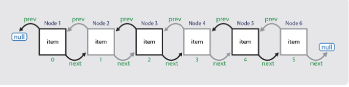

All work in LinkedList directed to links.

LinkedList adds methods to use it as a stack, a Queue or a double-ended queue (deque). Some of these methods are aliases or slight variations of each other, producing names familiar for a particular use ( Queue , in particular).

1) getFirst() and element() are identical—they return the head (first element) of the list without removing it, and throw NoSuchElementException if the List is empty. 2) peek() is a slight variation of those two that returns null if the list is empty. 3) removeFirst() and remove() are also identical—they remove and return the head of the list, and throw NoSuchElementException for an empty list. 4) poll() is a slight variation that returns null if this list is empty. 5) addFirst() inserts an element at the beginning of the list. 6) offer() is the same as add() and addLast(). They all add an element to the tail (end) of a list. 7) removeLast() removes and returns the last element of the list.

```java
import java.util.*;

public class LinkedListDemo {
    public static void main(String... args) {
        LinkedList<Integer> ll = new LinkedList<>();
        for (int i = 0; i <= 10; i++) {
            ll.add(i);
        }

        System.out.println(ll.getFirst()); // get the first element
        System.out.println(ll);
        System.out.println();

        System.out.println(ll.peek()); // get the head of the list but not remove it
        System.out.println(ll);
        System.out.println();

        System.out.println(ll.remove()); // retrives and removes the head of the list
        System.out.println(ll);
        System.out.println();

        System.out.println(ll.poll()); // retrives and removes the head of the list
        System.out.println(ll);
        System.out.println();

        ll.addFirst(100); // add the element as a first element
        System.out.println(ll);
        System.out.println();

        ll.offer(1000); // add the element to the tail of the list
        System.out.println(ll);
        System.out.println();

        ll.add(200); // add the element to the tail of the list
        System.out.println(ll);
        System.out.println();

        ll.add(5, 300); // add the element to the 5 index
        System.out.println(ll);
        System.out.println();
    }
}

LinkedListDemo.main();
```

```
0
[0, 1, 2, 3, 4, 5, 6, 7, 8, 9, 10]

0
[0, 1, 2, 3, 4, 5, 6, 7, 8, 9, 10]

0
[1, 2, 3, 4, 5, 6, 7, 8, 9, 10]

1
[2, 3, 4, 5, 6, 7, 8, 9, 10]

[100, 2, 3, 4, 5, 6, 7, 8, 9, 10]

[100, 2, 3, 4, 5, 6, 7, 8, 9, 10, 1000]

[100, 2, 3, 4, 5, 6, 7, 8, 9, 10, 1000, 200]

[100, 2, 3, 4, 5, 300, 6, 7, 8, 9, 10, 1000, 200]
```

All infocan be found using the link: https://docs.oracle.com/javase/7/docs/api/java/util/LinkedList.html

### Set

A Set refuses to hold more than one instance of each object value. If you try to add more than one instance of an equivalent object, the Set prevents duplication. The most common use for a Set is to test for membership, so you can easily ask whether an object is in a Set . Because of this, lookup is typically the most important operation for a Set , so you’ll usually choose a HashSet implementation, which is optimized for rapid lookup.

```java
import java.util.*;

public class SetDemo {
    public static void main(String... args) {
        Random r = new Random(100);
        Set<Integer> ints = new HashSet<>();
        for (int i = 0; i < 1000; i++) {
            ints.add(r.nextInt(20));
        }

        System.out.println(ints);
    }
}

SetDemo.main();
```

```
[0, 1, 2, 3, 4, 5, 6, 7, 8, 9, 10, 11, 12, 13, 14, 15, 16, 17, 18, 19]
```

One thousand random numbers from 0 to 19 are added to the set, so it is obviously that each value had many duplications. And as you can see no duplications exist in out Set.

The order maintained by a HashSet is different from a TreeSet or a LinkedHashSet , since each implementation has a different way of storing elements. TreeSet keeps elements sorted into a red-black tree data structure, whereas HashSet uses the hashing function. LinkedHashSet also uses hashing for lookup speed, but appears to maintain elements in insertion order using a linked list.

```java
import java.util.*;

public class SetOfStringsDemo {

    public static void main(String... args) {
        Set<String> colors = new HashSet<>();
        for (int i = 0; i < 100; i++) {
            colors.add("Green");
            colors.add("Black");
            colors.add("Cyan");
            colors.add("Yellow");
            colors.add("Gray");
            colors.add("White");
            colors.add("Blue");
        }

        System.out.println(colors);
    }
}

SetOfStringsDemo.main();
```

```
[Gray, Cyan, White, Yellow, Blue, Black, Green]
```

String objects don’t seem to produce an order. To sort the results, one approach is to use a **TreeSet** instead of a **HashSet**:

```java
import java.util.*;

public class SortedSetOfStringsDemo {

    public static void main(String... args) {
        Set<String> c = new TreeSet<>();
        for (int i = 0; i < 100; i++) {
            c.add("Green");
            c.add("Black");
            c.add("Cyan");
            c.add("Yellow");
            c.add("Gray");
            c.add("White");
            c.add("Blue");
        }

        System.out.println(c);
    }
}

SortedSetOfStringsDemo.main();
```

```
[Black, Blue, Cyan, Gray, Green, White, Yellow]
```

One of the most common operations is a test for set membership using contains():

```java
Set<String> mySet = new HashSet<>();
mySet.add("Hello");
System.out.println(mySet.contains("Hello"));
System.out.println(mySet.contains("World"));
```

```
true
false
```

```java
class SetOperationsDemo {

    public static void main(String... args) {
        Set<Integer> set1 = new HashSet<>();
        Collections.addAll(set1, 1, 2, 3, 4, 5);
        set1.add(6);
        System.out.println("set1 contains 1: " + set1.contains(1));
        System.out.println("set1 contains 7: " + set1.contains(7));

        Set<Integer> set2 = new HashSet<>();
        Collections.addAll(set2, 4, 5, 6);

        System.out.println("set1: " + set1);
        System.out.println("set2: " + set2);

        System.out.println("set2 contains all elements from set1: " + set2.containsAll(set1));
        System.out.println("set1 contains all elements from set2: " + set1.containsAll(set2));

        set1.removeAll(set2);
        System.out.println("set1: " + set1);
        Collections.addAll(set1, 7, 8, 9);
        Collections.addAll(set2, 7, 8, 9);
        System.out.println("set1: " + set1);
        System.out.println("set2: " + set2);

        set1.retainAll(set2);
        System.out.println("set1 and set2 intersection: " + set1);
    }
}

SetOperationsDemo.main();
```

```
set1 contains 1: true
set1 contains 7: false
set1: [1, 2, 3, 4, 5, 6]
set2: [4, 5, 6]
set2 contains all elements from set1: false
set1 contains all elements from set2: true
set1: [1, 2, 3]
set1: [1, 2, 3, 7, 8, 9]
set2: [4, 5, 6, 7, 8, 9]
set1 and set2 intersection: [7, 8, 9]
```

#### Practical usage of sets

Let's consider that we need to filter only unique words from a specific text:

```java
String text = "Please note:  neither this list nor its contents are final till\n" +
"midnight of the last day of the month of any such announcement.\n" +
"The official release date of all Project Gutenberg Etexts is at\n" +
"Midnight, Central Time, of the last day of the stated month.  A\n" +
"preliminary version may often be posted for suggestion, comment\n" +
"and editing by those who wish to do so.  To be sure you have an\n" +
"up to date first edition [xxxxx10x.xxx] please check file sizes\n" +
"in the first week of the next month.  Since our ftp program has\n" +
"a bug in it that scrambles the date [tried to fix and failed] a\n" +
"look at the file size will have to do, but we will try to see a\n" +
"new copy has at least one byte more or less.";

Set<String> uniqueWords = new HashSet<>();
Collections.addAll(uniqueWords, text.split("\\W+"));
System.out.println(uniqueWords);

System.out.println(text.split("\\W+").length);
System.out.println(uniqueWords.size());
```

[output not shown]